# Applied Bayesian Analyses in R

Part 3

Sven De Maeyer

## New example data `WritingData.RData`

- Experimental study on Writing instructions
- 2 conditions:
  - Control condition (Business as usual)
  - Experimental condition (Observational learning)

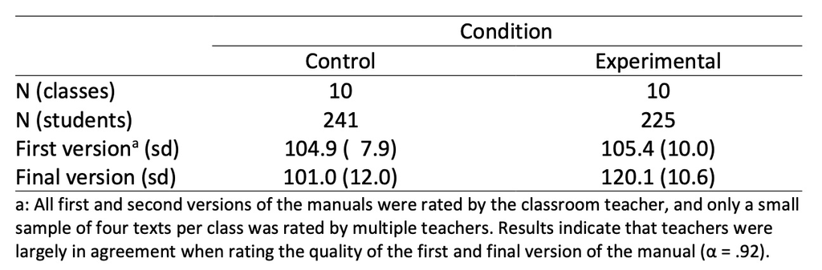

## Your Turn

- Open `WritingData.RData`
- Estimate 3 models with `SecondVersion` as dependent variable
  - M1: fixed effect of `FirstVersion_GM` + random effect of `Class` (`(1|Class)`)
  - M2: M1 + random effect of `FirstVersion_GM` (`(1 + FirstVersion_GM |Class)`)
  - M3: M2 + fixed effect of `Experimental_condition`
- Compare the models on their fit
- What do we learn?
- Make a summary of the best fitting model

Note: `FirstVersion_GM`is the score of the pretest centred around the mean, so a score 0 for this variable implies scoring on average for the pretest

## Divergent transitions…

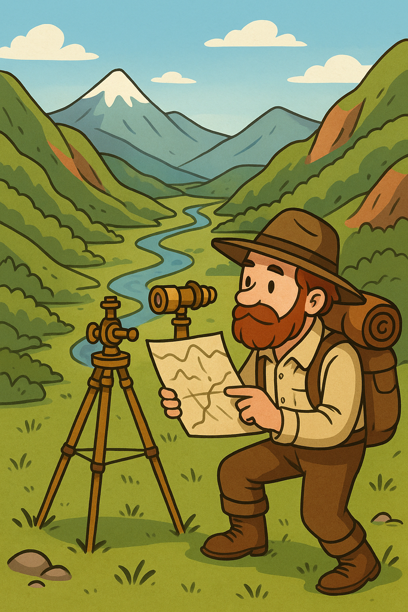

Exploring the parameter space…

[interactive chart not shown]

## Divergent transitions…

- Something to worry about!
- Essentially: sampling of parameter estimate values went wrong
- Fixes:
  - sometimes fine-tuning the sampling algorithm (e.g., `control = list(adapt_delta = 0.9)`) works
  - sometimes you need more informative priors
  - sometimes the model is just not a good model

## Our fix here for model 3

```r
M3 <- brm(
  SecondVersion ~ FirstVersion_GM + Experimental_condition + (1 + FirstVersion_GM |Class),
  data = WritingData,
  backend = "cmdstanr",
  cores = 4,
  control = list(adapt_delta = 0.9),
  seed = 1975
)
```

## Our fix here for model 3

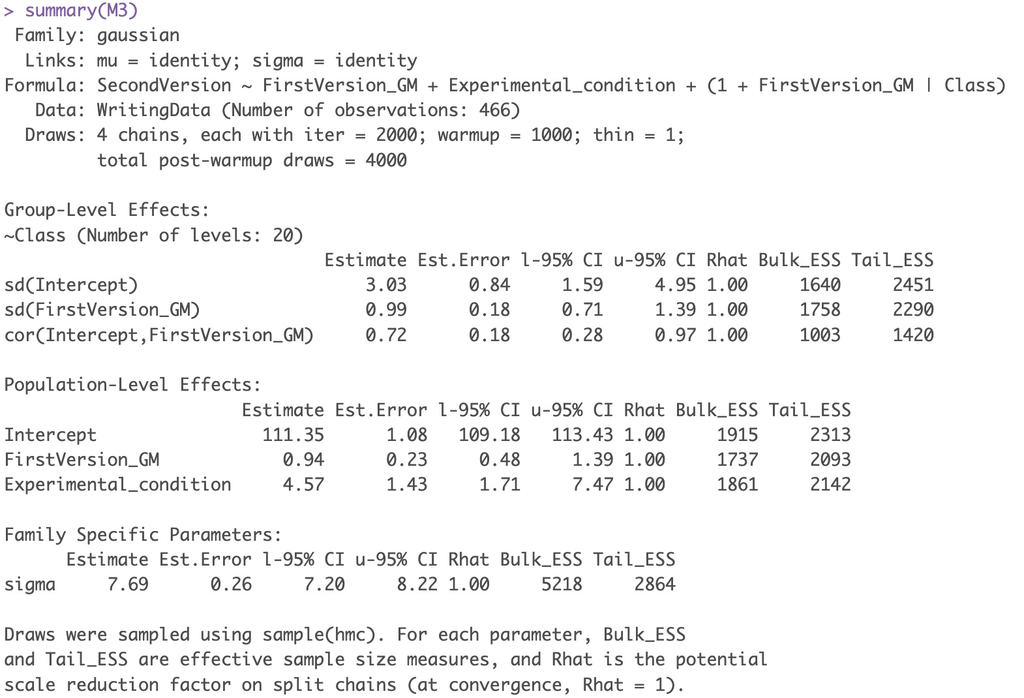

## Interpretation of results…

Different ways to summarize our results:

- visually
- credible intervals (eti & hdi)
- rope + hdi rule
- hypothesis tests

# Visually summarizing the posterior distribution

## Functions in `bayesplot` package

- `mcmc_areas()` function
- `mcmc_areas_ridges()` function
- `mcmc_intervals()` function

## The `mcmc_areas()` function

Gives a posterior distribution including a certain credible interval that you can set manually with the `prob` argument:

```r
mcmc_areas(
  M3,
  pars = c(
    "b_FirstVersion_GM",
    "b_Experimental_condition"
  ),
  prob = .89
)
```

## The `mcmc_areas()` function

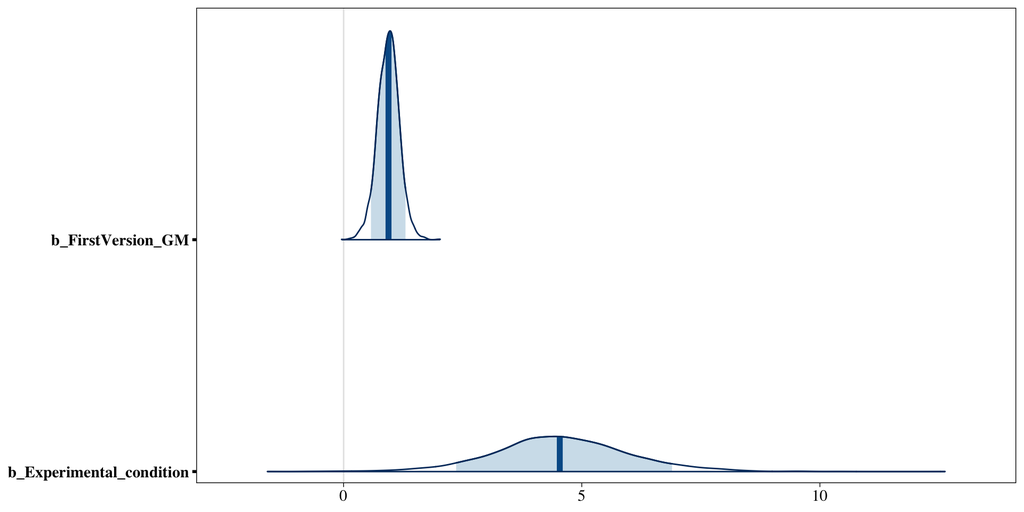

## The `mcmc_areas_ridges()` function

Almost similar to the previous, only the horizontal spacing changes a bit…

Meanwhile, see how you can easily change the color scheme for `bayesplot` graphs

```r
color_scheme_set(scheme = "red")

mcmc_areas_ridges(
  M3,
  pars = c(
    "b_FirstVersion_GM",
    "b_Experimental_condition"
  ),
  prob = .89
)
```

## The `mcmc_areas_ridges()` function

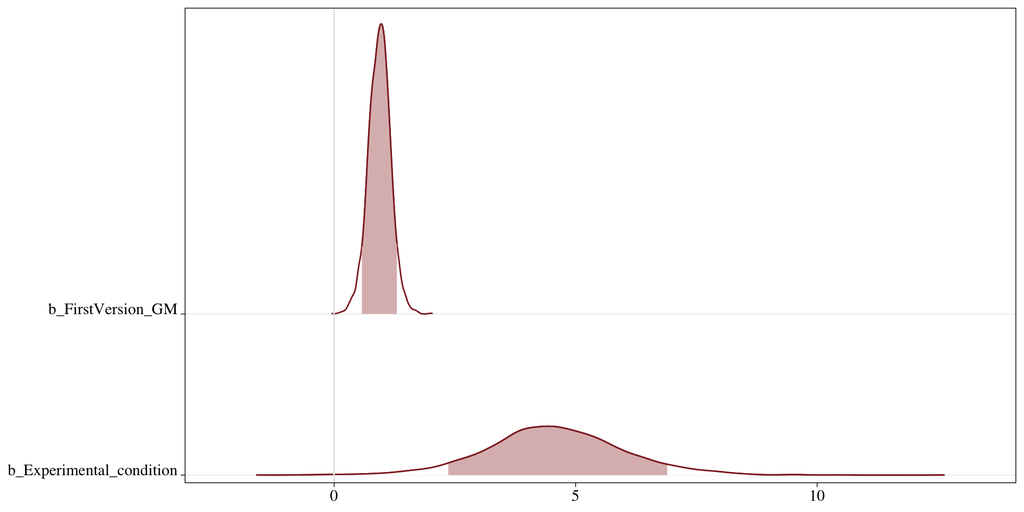

## The `mcmc_intervals()` function

Summarizes the posterior as a horizontal bar with identifiers for two CI.

Here we set one for a 50% and one for a 89% CI

```r
color_scheme_set(scheme = "gray")

mcmc_intervals(
  M3,
  pars = c(
    "b_FirstVersion_GM",
    "b_Experimental_condition"
  ),
  prob = .5,
  prob_outer = .89
)
```

## The `mcmc_intervals()` function

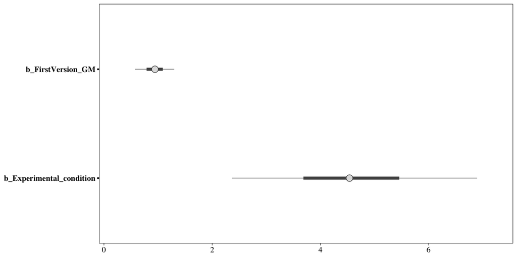

## Manually create visualizations

Powercombo: `as_draws_df()` + `ggplot2` + `ggdist`

What does `as_draws_df()` do?

```r
posterior_PD <- as_draws_df(M3)
head(posterior_PD)
```

## Manually create visualizations

```
# A draws_df: 6 iterations, 1 chains, and 49 variables
  b_Intercept b_FirstVersion_GM b_Experimental_condition sd_Class__Intercept
1         113              0.98                      4.7                 5.2
2         112              1.47                      5.1                 2.8
3         113              1.07                      3.5                 2.8
4         111              1.09                      4.7                 4.2
5         112              1.08                      4.0                 1.7
6         111              1.04                      5.0                 2.4
  sd_Class__FirstVersion_GM cor_Class__Intercept__FirstVersion_GM sigma
1                      0.93                                  0.77   7.4
2                      1.06                                  0.68   8.1
3                      0.88                                  0.79   7.1
4                      0.75                                  0.74   8.0
5                      0.94                                  0.78   7.1
6                      0.97                                  0.82   8.1
  r_Class[1,Intercept]
1                 1.84
2                -1.59
3                -0.60
4                 0.95
5                 0.81
6                 0.38
# ... with 41 more variables
# ... hidden reserved variables {'.chain', '.iteration', '.draw'}
```

## Use draws to create a plot using `ggdist` geoms

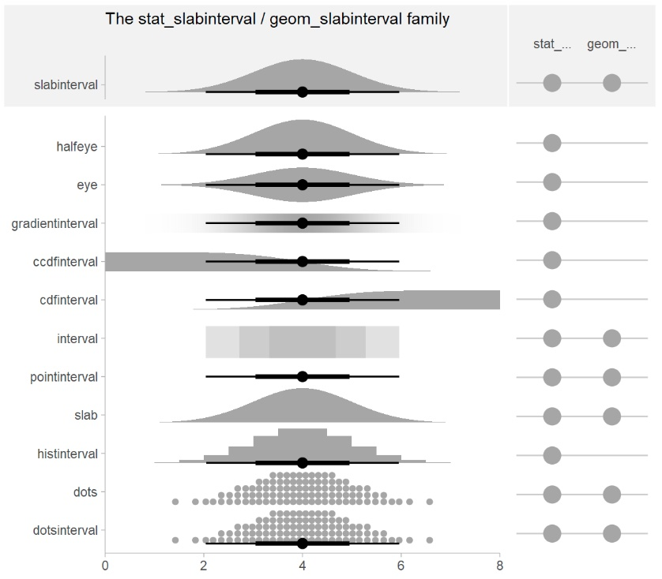

`ggdist` package has a set of functions to visualize a distribution

## An example

Before we start, set our own plot theme (not so necessary)

```r
# Setting a plotting theme
theme_set(theme_linedraw() +
            theme(
              text = element_text(family = "Times", size = 14),
              panel.grid = element_blank()
              )
)
```

## An example

We use `posterior_PD` as a starting point (our draws)

```r
library(ggdist)

Plot <- ggplot(
  posterior_PD,
  aes(x = b_Experimental_condition)
  ) +
  stat_halfeye()

Plot + scale_y_continuous(name = "", breaks = NULL)
```

## An example

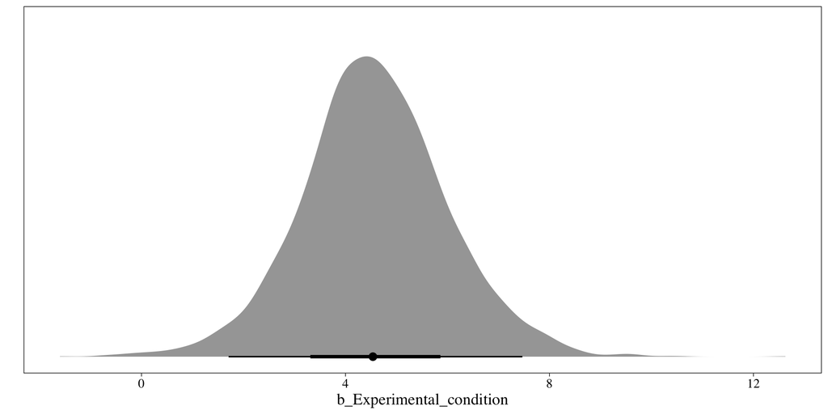

## Change the CI’s

Change the CI’s to 50% and 89%

```r
Plot <- ggplot(
  posterior_PD,
  aes(x = b_Experimental_condition)
  ) +
  stat_halfeye(
    .width = c(.50,.89)
  )

Plot + scale_y_continuous(name = "", breaks = NULL)
```

## Change the CI’s

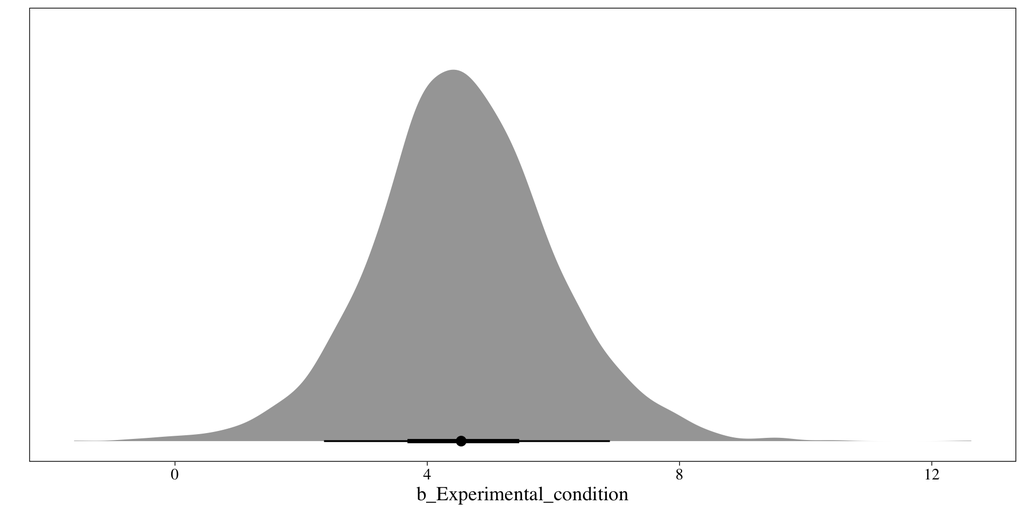

## Use another visualization

Let’s make a dotplot… (research shows this is best interpreted) with 100 dots

```r
Plot <- ggplot(
  posterior_PD,
  aes(x = b_Experimental_condition)
  ) +
  stat_dotsinterval(
    quantiles = 100,
    .width = c(.50,.89)
  )

Plot + scale_y_continuous(name = "", breaks = NULL)
```

## Use another visualization

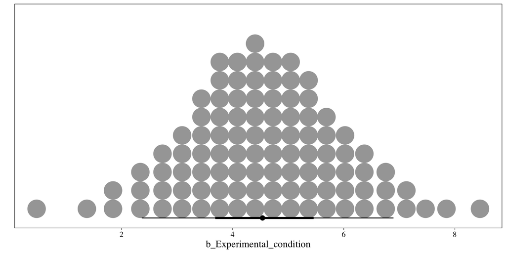

## Plot two parameters each in a facet

We use `pivot_longer(everything())` to stack information on multiple parameters

```r
posterior_PD %>%
  select(
    b_Experimental_condition, b_FirstVersion_GM
  ) %>%
  pivot_longer(everything()) %>%
  ggplot(
    aes(x = value)
  ) +
  stat_halfeye(
    .width = c(.50,.89)
  ) +
facet_wrap(name ~ .) +
scale_y_continuous(name = "", breaks = NULL)
```

## Plot two parameters each in a facet

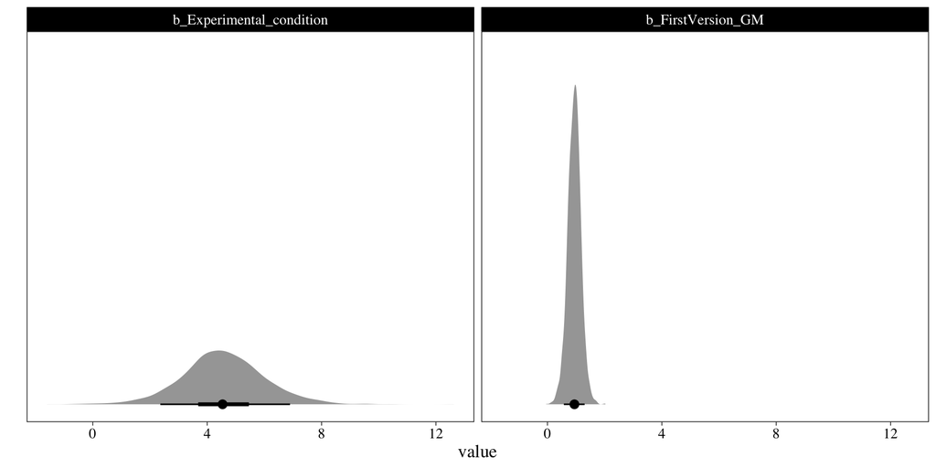

## Visualize calculated predictions based on posterior

Our example: 2 groups according to `Experimental_condition`

How to visualize the posterior probability of averages for both groups?

```r
posterior_PD %>%
  select(
    b_Intercept, b_Experimental_condition
  ) %>%
  mutate(
    Mean_Control_condition = b_Intercept,
    Mean_Experimental_condition = b_Intercept + b_Experimental_condition
  ) %>%
  select(
    Mean_Control_condition, Mean_Experimental_condition
  ) %>%
  pivot_longer(everything()) %>%
  ggplot(
    aes(x = value, color = name, fill = name)
  ) +
  stat_halfeye(
    .width = c(.50,.89),
    alpha = .40
  ) +
  scale_y_continuous(name = "", breaks = NULL)
```

## Visualize calculated predictions based on posterior

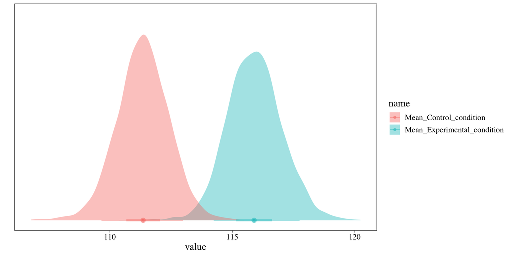

## Hypothetical Outcome Plots (HOPs)

Code: see separate script called `HOP_script.R`

```
# A tibble: 6 × 3
   draw     X Pred1
  <int> <dbl> <dbl>
1     1 -15    95.8
2     1 -14.9  95.9
3     1 -14.8  96.0
4     1 -14.7  96.1
5     1 -14.6  96.2
6     1 -14.5  96.3
```

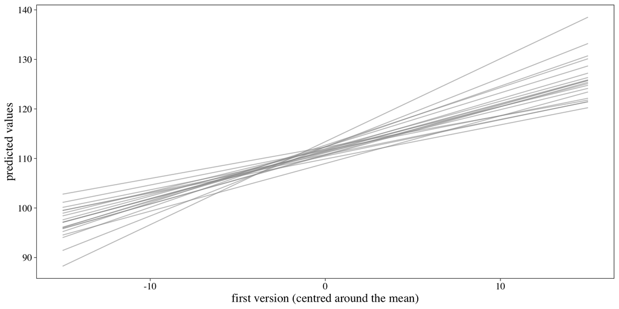

# Visualizing Random Effects

## Plotting the residuals

To plot differences between classes we can use class-specific residuals:

```r
head(as_draws_df(M3) %>%
  select(ends_with(",Intercept]")) %>%
  select(1:3),
  5
)
```

```
# A tibble: 5 × 3
  `r_Class[1,Intercept]` `r_Class[2,Intercept]` `r_Class[3,Intercept]`
                   <dbl>                  <dbl>                  <dbl>
1                  1.84                  1.36                  -4.38
2                 -1.59                  3.12                   0.0290
3                 -0.595                 2.02                  -0.347
4                  0.945                 2.50                  -2.55
5                  0.815                -0.0404                -1.59
```

## Plotting the residuals

```r
as_draws_df(M3) %>%
  select(ends_with(",Intercept]")) %>%
  pivot_longer(starts_with("r_Class")) %>%
  mutate(sigma_i = value) %>%
  ggplot(aes(x = sigma_i, y = reorder(name, sigma_i))) +
  stat_pointinterval(
    point_interval = mean_qi,
    .width = .89,
    size = 1/6) +
  scale_y_discrete(expression(italic(j)), breaks = NULL) +
  labs(x = expression(italic(u)[italic(j)])) +
  coord_flip()
```

## Plotting the residuals

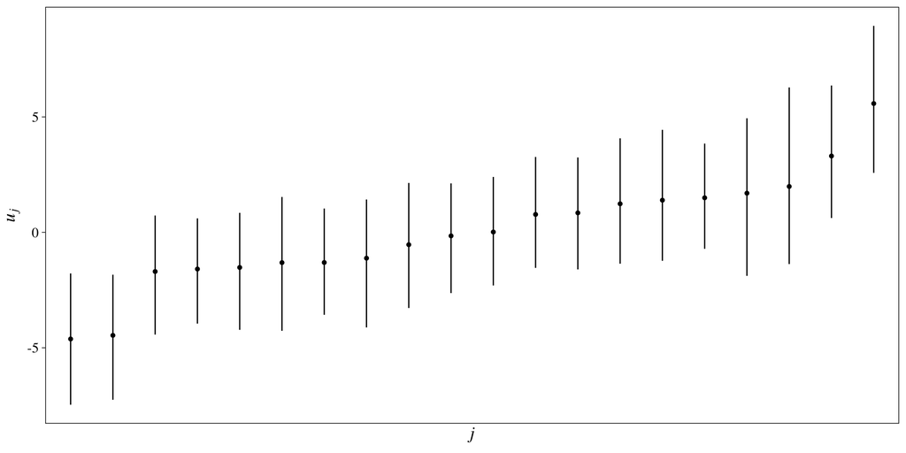

## ICC estimation

```r
head(
  as_draws_df(M3) %>%
    mutate(
      ICC = (sd_Class__Intercept^2/(sd_Class__Intercept^2 + sigma^2))) %>%
    select(sigma, sd_Class__Intercept, ICC),
  5
  )
```

```
# A tibble: 5 × 3
  sigma sd_Class__Intercept    ICC
  <dbl>               <dbl>  <dbl>
1  7.36                5.24 0.336
2  8.07                2.77 0.106
3  7.10                2.76 0.131
4  8.01                4.18 0.214
5  7.11                1.71 0.0545
```

## ICC estimation

```r
as_draws_df(M3) %>%
  mutate(
    ICC = (sd_Class__Intercept^2/(sd_Class__Intercept^2 + sigma^2))
    ) %>%
  select(ICC) %>%
  ggplot(aes(x = ICC)) +
   stat_dotsinterval(
     quantiles = 100,
     .width = c(.50,.89)
   ) +
   scale_x_continuous("marginal posterior",
                      breaks = seq(.00,.60,by =.05)) +
   scale_y_continuous("ICC", breaks = NULL)
```

## ICC estimation

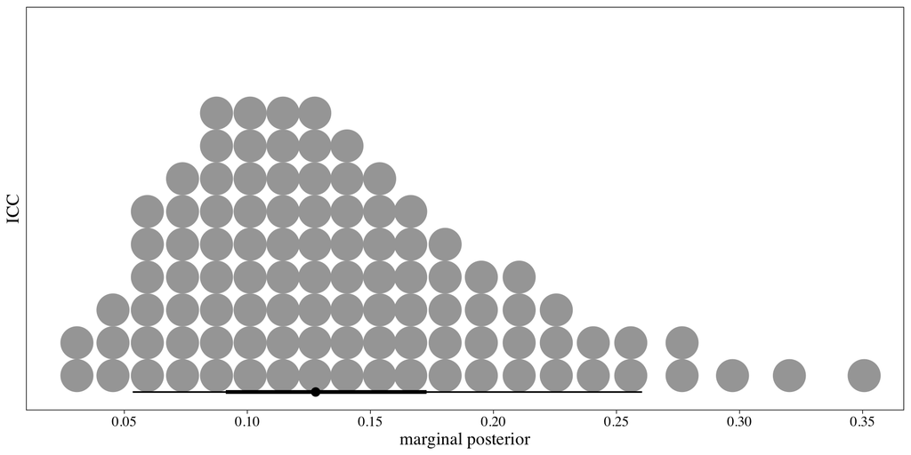

## HOP per higher level unit

Code: see separate script called `HOP_MixedEffects_script.R`

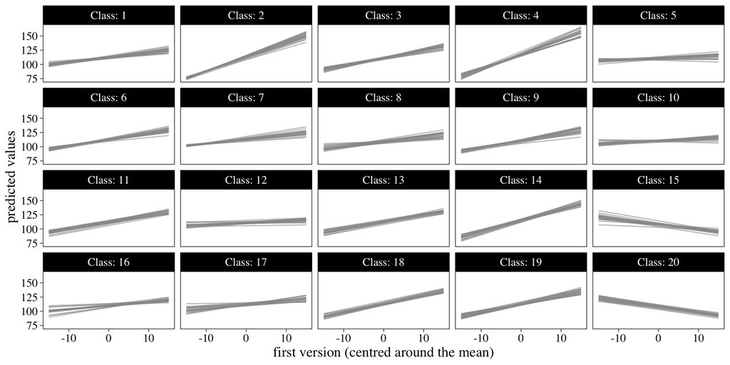

# Reporting stats about the posterior

## Credible Intervals

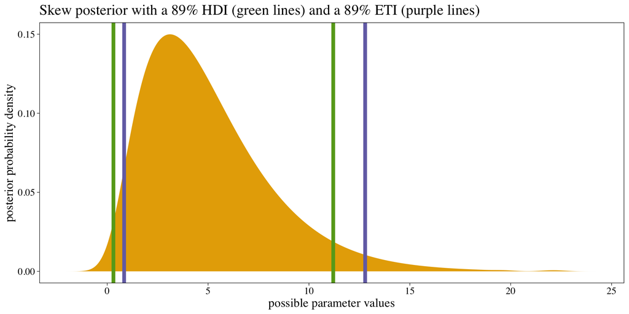

- ETI: Equal Tailed Interval
- HDI: Highest Density Interval

## Concept of ROPE

[figure not shown]

**ROPE**: Region Of Practical Equivalence

*Set a region of parameter values that can be considered equivalent to having no effect*

- in standard effect sizes the advised default is a range of -0.1 to 0.1
- this equals 1/2 of a small effect size (Cohen, 1988)
- all parameter values in that range are set equal to no effect

## ROPE + HDI

[figure not shown]

**ROPE + HDI rule**

- 95% of HDI out of ROPE $\rightarrow$ $H_0$ rejected
- 95% of HDI all in ROPE $\rightarrow$ $H_0$ not rejected
- 95% of HDI partially out of ROPE $\rightarrow$ undecided

## Applying the HDI + ROPE rule with `bayestestR` package

We can use the `equivalence_test()` function of the `bayestestR` package

```r
library(bayestestR)
equivalence_test(M3)
```

```
# Test for Practical Equivalence

  ROPE: [-1.68 1.68]

Parameter              |       H0 | inside ROPE |          95% HDI
------------------------------------------------------------------
Intercept              | Rejected |      0.00 % | [109.18, 113.43]
FirstVersion_GM        | Accepted |    100.00 % |     [0.48, 1.39]
Experimental_condition | Rejected |      0.00 % |     [1.71, 7.47]
```

## Visualizing the HDI + ROPE rule

We visualize the `equivalence_test()` by adding `plot( )`

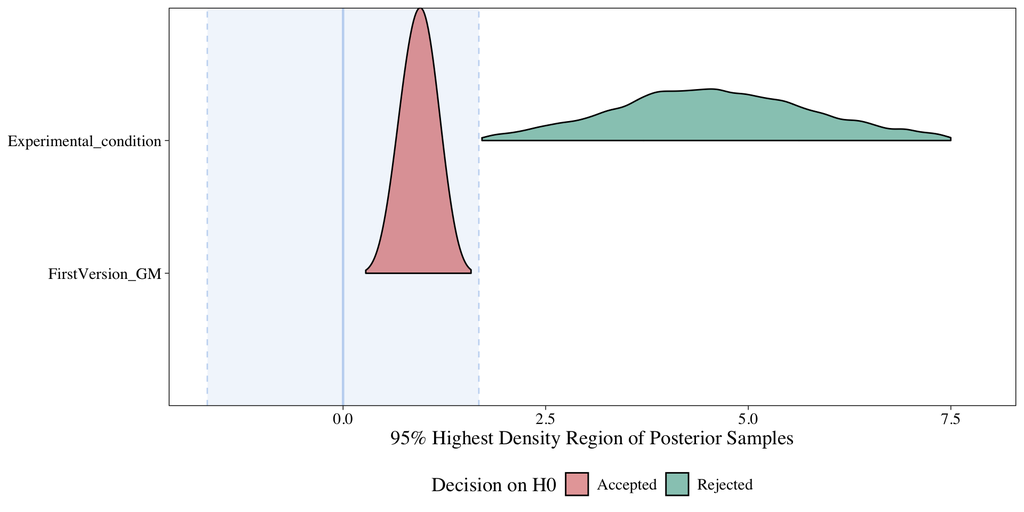

```r
equivalence_test(M3) %>%
  plot()
```

## Probability of Direction (PD) with `parameters` package

```r
library(parameters)
model_parameters(
  M3,
  ci_method = "hdi",
  rope_range = c(-1.8,1.8), #sd MarathonTimeM = 17.76 so 17.76*0.1
  test = c("rope", "pd")
  )
```

```
# Fixed Effects

Parameter              | Median |           95% CI |     pd | % in ROPE |  Rhat |     ESS
-----------------------------------------------------------------------------------------
(Intercept)            | 111.36 | [109.34, 113.58] |   100% |        0% | 1.000 | 1925.00
FirstVersion_GM        |   0.94 | [  0.49,   1.40] | 99.98% |      100% | 1.001 | 1718.00
Experimental_condition |   4.54 | [  1.77,   7.52] | 99.75% |     0.21% | 0.999 | 1814.00

# Sigma

Parameter | Median |       95% CI |   pd | % in ROPE |  Rhat |     ESS
----------------------------------------------------------------------
sigma     |   7.68 | [7.19, 8.20] | 100% |        0% | 1.001 | 5235.00
```

# Outro

## Some books

[figure not shown]

## Some books

[figure not shown]

## Some free online books

- Bayes Rules!:

https://www.bayesrulesbook.com/

- Or this book:

https://vasishth.github.io/bayescogsci/book/

## Rens van de Schoot

In *Nature Reviews*

[figure not shown]

## THE Podcast

If you like running - like I do - this could be a great companion on your run!

https://www.learnbayesstats.com/

## Site on creating the graphs

There are many blogs and websites that you can consult if you want to find out more about making graphs.

One that I often fall back to is:

http://mjskay.github.io/tidybayes/

## Questions?

Do not hesitate to contact me!

sven.demaeyer@uantwerpen.be